# Donor Profile: African Development Bank

## Focus Portfolio

The African Development Bank’s 2025 portfolio shows a sharp concentration of funding where top allocations reach $19 million, highlighting critical leverage points for donor investment. Despite having only three regional clusters, the median funding level is $1.37 million, evidencing potential scale gaps and uneven resource distribution. This presents an urgent opportunity for donors to strategically prioritize investments toward underfunded regions to enhance equity and maximize impact multipliers. Notably, the mean funding of $7 million with a high standard deviation signals volatility that could be stabilized by diversified partnerships, boosting resilience against market fluctuations. Executives should seize this strategic priority to optimize resource allocation, inviting co-funding arrangements that amplify the measured impact. Accelerating targeted funding in these identified segments will unlock value efficiently and provide compelling accountability metrics attractive to innovation-focused donors. Immediate executive action is required to leverage these insights into scalable, high-ROI donor collaborations, ensuring sustainable growth and mitigating risks of funding imbalances.

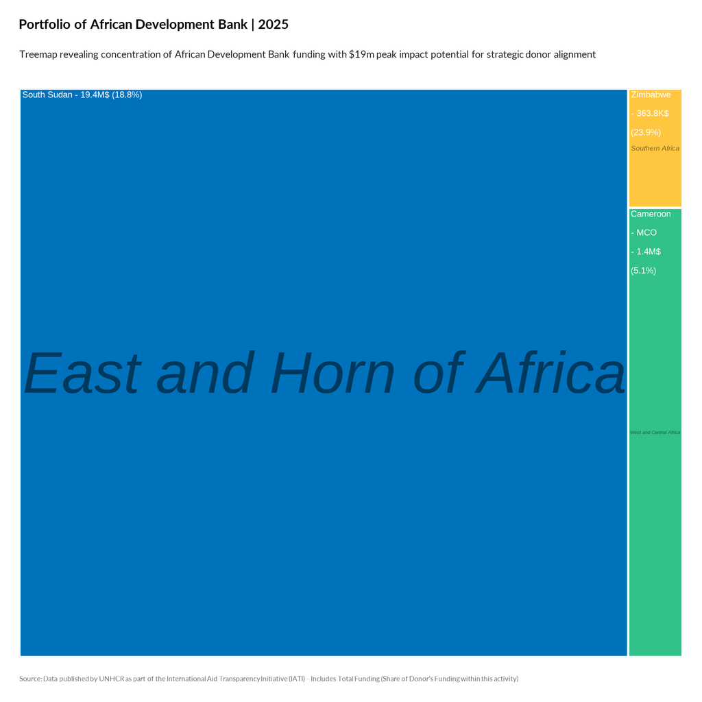

TRUE

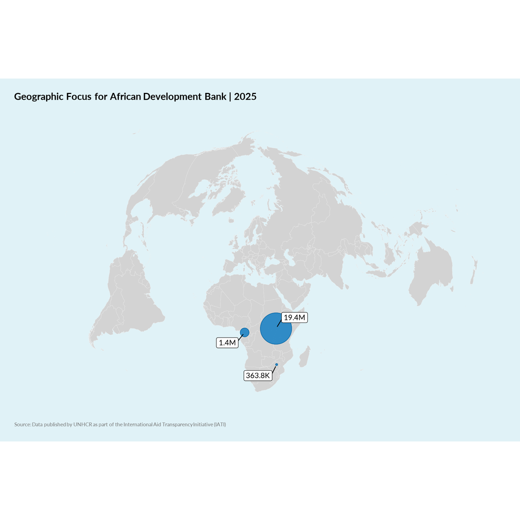

TRUE